# Skaitliskā optimizācija

### Problēmas nostādne

Matemātiskajā optimizācija tiek aplūkotas problēmas, kur tiek minimizēta (maksimizēta) kāda funkcija f(x). Piemēram, atrast minimālo vērtību funkcijai $ x^{2} $. Šāds punkts tiek saukts par ekstrēma punktu. Ir iespējams nodalīt lokālos un globālos ekstrēma punktus.

- Punkts $x^{*}$ ir lokāls ekstrēma punkts, ja visiem punktiem x no punkta $x^{*}$ apkārtnes izpildās: $f(x) \geq f(x^{*})$
- Punkts $x^{*}$ ir globāls ekstrēma punkts, ja visiem punktiem $x$ izpildās: $f(x) \geq f(x^{*})$

Piemēram funkcija $x^{2}$ savu minimuma vērtību sasniedz punktā $x=0$ un tas ir globālais ekstrēma punkts. Taču funkcijai $sin(x)$ ir bezgalīgi daudz globālie minimuma punkti, jo funkcija pieņem savu minimālo vērtību $-1$ bezgalīgi daudz punktos.

Bet kā atrast ekstrēma punktus? Atgriezīsimies pie $f(x) = x^{2}$. Viena no pieejām ir uzzīmēt funkciju grafiksi:

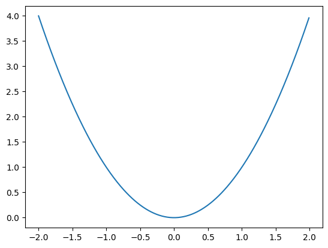

```python
import numpy as np
import matplotlib.pyplot as plt

xxx = np.arange(-2,2, 0.01)

plt.plot(xxx, xxx**(2))
plt.show()
```

Vai arī var lietot metodes no matemātiskās analīzes. Atrast funkcijas atvasinājumu: $f'(x) = 2 x $ un to pielīdzināt nullei $2x = 0 \implies x =0 $.

Svarīgi atcerēties, ka nosacījums $ f'(x) = 0 $ ir nepieciešamais nosacījums, lai punkts būtu ekstrēms, nevis pieteikamais nosacījums. Tas nozīmē, ja kādā punktā $ f'(x) = 0$, tas vēl nenozīmē, ka ir atrast ekstrēma punkts. Piemēram, funckijai $x^{3}$ punktā $x=0$ izpildās: $f'(0) = 3 \cdot 0^{2} = 0 $, taču punkts nav ne maksimuma, ne minimuma punkts.

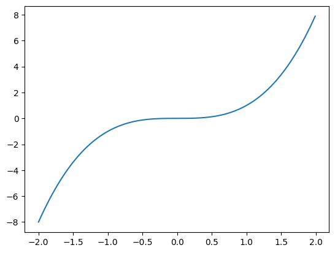

```python
plt.plot(xxx, xxx**3)
plt.show()
```

Taču meklēt funkcijas atvasinājumu un pielīdzināt to nullei vai aplūkot funkcijas grafiku ne vienmēr ir optimāli. Piemēram, aplūkojot vairāku argumentu funkcijas.

Tāpēc viens no risinājumiem ir meklēt ekstrēma punktus skaitliski un iegūt tuvinātus atrisinājumus.

## Ieskas gradienta metodē

Aplūkosim funkciju $f(x) = x^{2}$ un pieņemsim, ka mēs nezinam, ka tā pieņem savu minimālo vērtību punktā $x=0$. Mēs varam atcerēties vēl kādu īpašību par funkcijas atvasinājumu. Funkcijas atvasinājums punktā $x$ rāda uz to, kā funkcija mainās šī punkta apkārtnē. Ja atvasinājums ir pozitīvs, tad punkta $x$ apkārtnē funkcija aug. Piemēram, funkcijas $x^{2}$ atvasinājums $2x $ punktā $x=1$ pieņem vērtību $2$. Arī augstāk grafikā var redzēt, ka punkta $x=1 $ apkārtnē funkcija aug. Tas ir, ja punktā $x=1$, mēs sākut iet pa $X$ asi uz labo pusi, funkcijas vērtība palielinātos. Turpretim, punktā $x=-1$ notiek pretējais. Funkcijas atvasinājums ir negatīvs, līdz ar to, ejot uz priekšu pa $X$ asi, funkcijas vērtība samazinās šī punkta apkārtnē.

Taču šāds novērojums dod ideju sekot funkcijas atvasinājumam, iet pretējā virzineā tam. Ja atvasinājums ir pozitīvs punktā $x$, tad jāiet pa kreisi no šī punkta un ja atvasinājums ir negatīvs, tad jāiet pa labi no šī punkta. To var pierakstīt:

$$x_{k+1} = x_{k} - h \cdot f'(x_{k}) $$

- Pieņemsim, ka $x_{0} = 3$ (šis punkts ir pānemts patvaļīgi. Nav olbigāti jāņem 3.). Tālāk aprēķina $f'(x_{0}) = f'(3) = 2 \cdot 3 = 6$. Un pēc tam aprēķina $x_{1} = x_{0} - h \cdot f'(x_{0}) = 3 - 0.1 \cdot 6 = 2.4 $
- Aprēķina $f'( x_{1}) = f'( 2.4) = 4.8 $ un pēc tam $x_{2} = x_{1} - h \cdot f'(x_{1}) = 2.4 - 0.1 \cdot 4.8 = 1.92$.
- Aprēķina $f'(x_{2}) = f'(1.92) = 3.84 $ un pēc tam $ x_{3} = x_{2} - h \cdot f'(x_{2}) = 1.92 - 0.1 \cdot 3.84 = 1.536$

Un šādi var turpināt, taču cik ilgi? Mēs varam atcerēties, ka viens no nosacījumiem ekstēma punktiem ir, ka atvasinājums ir vienāds ar nulli. Līdzīgi šeit, mēs varētu turpināt iterācijas, līdz tiktu atrast punkts $x_{n}$, kuram $ f'(x_{n}) = 0$. Taču lai skaitliski atrastu punktu, kur atvasinājums ir precīzi vienāds ar nulli, var prasīt pārāk daudz laika. Tāpēc optimālāk būtu meklēt, līdz atvasinājums ir pietiekami mazs. Piemēram, atkārtot iterācijas, līdz $f'(x_{k}) \leq 10^{-6}$.

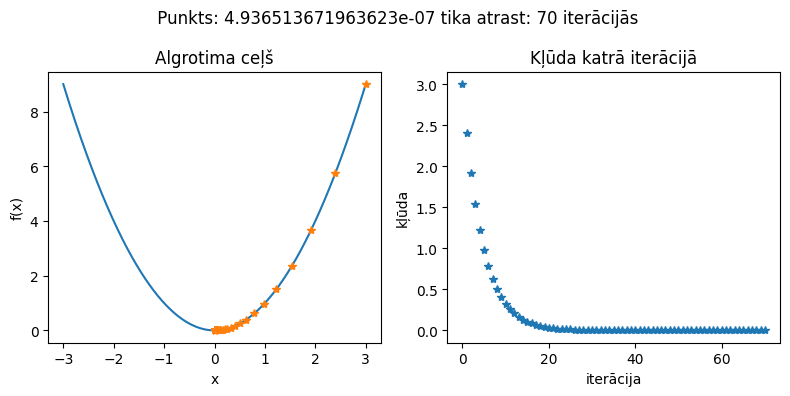

```python
x0 = 3
delta_f = lambda x: 2*x
xxx = np.arange(-3,3,0.01)
iter = [x0]

while np.abs(delta_f(x0)) >=  10**(-6):

    x0 = x0 - 0.1*delta_f(x0)

    iter.append(x0)

iter = np.array(iter)
fig, axs = plt.subplots(1, 2, figsize=(8, 4))
fig.suptitle(' Punkts: ' +  str(x0) +  " tika atrast: " + str(len(iter)-1) +  " iterācijās")
axs[0].plot(xxx,  xxx**2)
axs[0].plot(iter,iter**2, "*")
axs[0].set_title('Algrotima ceļš')
axs[1].plot(np.abs(iter - 0), '*')
axs[1].set_title('Kļūda katrā iterācijā')
axs[0].set_xlabel('x')
axs[0].set_ylabel('f(x)')
axs[1].set_xlabel('iterācija')
axs[1].set_ylabel('kļūda')
plt.tight_layout()
plt.show()
```

Var redzēt, ka 70 iterācijās algoritms var pietuvoties pietiekami tuvu nullei. Grafikā pa labi var redzēt, cik tālu no punkta $x=0$ atradodas $ x_{k}$.

Šajā piemērā nebija svarīga $x_{0}$ izvēle, jo funkcijai ir tikai viens ekstrēma punkts. Taču aplūkosim funkciju:

$$ f(x) = sin(3x) + 3 sin(x) $$

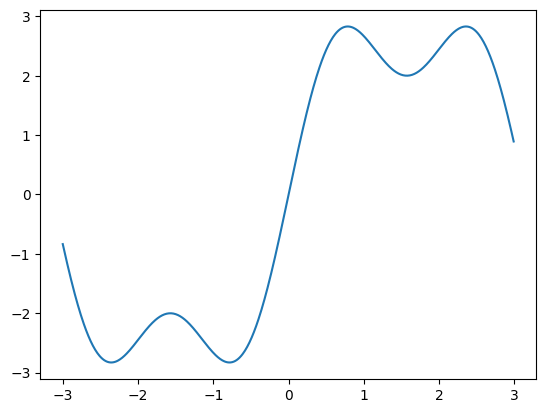

```python
plt.plot(xxx,np.sin(3*xxx) + 3*np.sin(xxx))
plt.show()
```

Šajā piemērā var iegūt dažādus atrisinājums atšīrībā no sākuma punkta.

```
ekstrēma punkts:  -0.7853981904611297  tika sasniegts:  10  itreācijās
ekstrēma punkts:  1.5707962201790775  tika sasniegts:  23  itreācijās
```

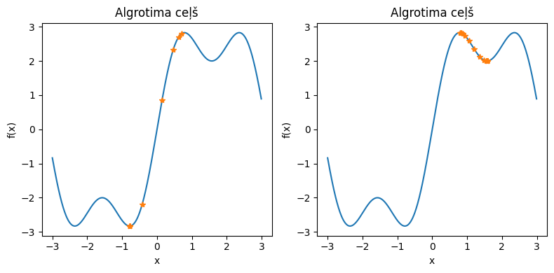

```python
x0 = 0.7
delta_f = lambda x: 3 * np.cos(3*x) + 3 * np.cos(x)
xxx = np.arange(-3,3,0.01)
iter = [x0]
# Ņemot x0 = 0.7
while np.abs(delta_f(x0)) >=  10**(-6):
    x0 = x0 - 0.1*delta_f(x0)
    iter.append(x0)

iter = np.array(iter)
fig, axs = plt.subplots(1, 2, figsize=(8, 4))
axs[0].plot(xxx,  np.sin(3*xxx) + 3*np.sin(xxx))
axs[0].plot(iter,np.sin(3*iter) + 3*np.sin(iter), "*")
axs[0].set_title('Algrotima ceļš')
print("ekstrēma punkts: ", x0, " tika sasniegts: " , len(iter)-1, " itreācijās ")

#Ņemot x0 = 0.8
x0 = 0.8
iter = [x0]
while np.abs(delta_f(x0)) >=  10**(-6):
    x0 = x0 - 0.1*delta_f(x0)
    iter.append(x0)

iter = np.array(iter)
axs[1].plot(xxx,  np.sin(3*xxx) + 3*np.sin(xxx))
axs[1].plot(iter,np.sin(3*iter) + 3*np.sin(iter), "*")
axs[1].set_title('Algrotima ceļš')
print("ekstrēma punkts: ", x0, " tika sasniegts: " , len(iter)-1, " itreācijās ")
axs[0].set_xlabel('x')
axs[0].set_ylabel('f(x)')
axs[1].set_xlabel('x')
axs[1].set_ylabel('f(x)')
plt.tight_layout()
plt.show()
```

Diemžēl, lietojot gradientu, lai pārvietotos, nav zāļu, kā cīnīties pret to, ka funkcija sasniedz lokālo, nevis globālo ekstrēma punktu. Tāpēc var gradienta metodi ir ieteicams lietot izliektām funkcijām. Funkciju $f(x)$ sauc par izliektu, ja visiem $t$, kur $ 0 \leq t \leq 1$ un visiem $x_{1}, x_{2}$ ir spēkā:

$$ f(t x_{1} + (1-t)x_{2}) \leq t f(x_{1}) + (1-t) f(x_{2})$$

Tas nozīmē, ka paņemot jebkurus divus punktus, starp šiem punktiem var novilkt taisni un šī taisne būs virs funkcijas :

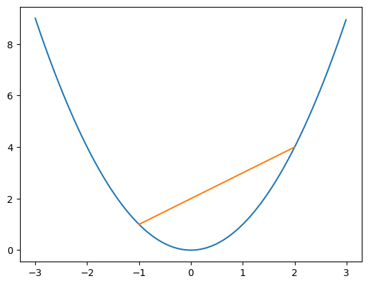

```python
t = np.arange(0,1,0.01/3)
xx = np.arange(-1,2,0.01)
x1 = -1
x2 = 2

plt.plot(xxx, xxx**2)
plt.plot(xx, t* x2**2 + (1-t)* x1**2)
plt.show()
```

Piemēram ņemot $x_{1} = -1 $ un $x_{2}= 2$, tos var savienot un funkcija starp šiem punktiem ir zem taismens.

### Soļa garums

Atgriezīsimies pie $ x_{k+1} =x_{k} - h \cdot f'(x_{k})$ un aplūkosim soļa garumu. Varbūt solis $h=0.1$ nav tas optimālākais. Vai arī varbūt konstnats soļa garums nav tas optimālākāis. Intuitīvi, pirmajās iterācijās būtu vēlams aplūkot mazāku soļa garumu, taču pietuvojoties ekstrēma punktam, kad atvasinājums ir mazs, varbūt būtu ieteicams ņemt mazāku soļa garumu.

Viena no pieejam varētu būt meklēt soļa garumu, kā funkciju no iterācijas. Piemēram: $h_{k} = \frac{1}{ \sqrt{k + 1}} $. Tiek pieskaitīts 1, jo pirmā iterācija ir $k=0$. Aplūkojam vēlreiz $f(x) = x^{2}$:

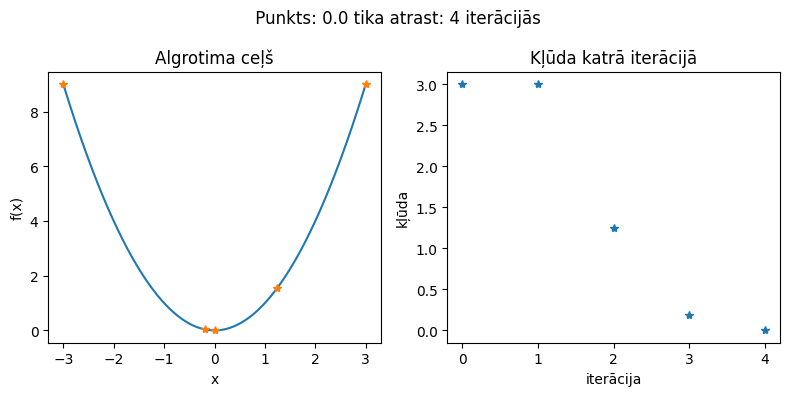

```python
x0 = 3
delta_f = lambda x: 2*x
xxx = np.arange(-3,3,0.01)
iter = [x0]

while np.abs(delta_f(x0)) >=  10**(-6):

    x0 = x0 - delta_f(x0)/ np.sqrt(len(iter))

    iter.append(x0)

iter = np.array(iter)
fig, axs = plt.subplots(1, 2, figsize=(8, 4))
fig.suptitle(' Punkts: ' +   str(round(x0,2)) +  " tika atrast: " + str(len(iter)-1) +  " iterācijās")
axs[0].plot(xxx,  xxx**2)
axs[0].plot(iter,iter**2, "*")
axs[0].set_title('Algrotima ceļš')
axs[1].plot(np.abs(iter - 0), '*')
axs[1].set_title('Kļūda katrā iterācijā')
axs[0].set_xlabel('x')
axs[0].set_ylabel('f(x)')
axs[1].set_xlabel('iterācija')
axs[1].set_ylabel('kļūda')
plt.tight_layout()
plt.show()
```

Var redzēt, ka punkts $x=0$ tiek sasniegts krienti ātrāk, nekā tas bija iepriekš.

Aplūkosim funkciju $f(x)= \frac{x^{2}}{10}$:

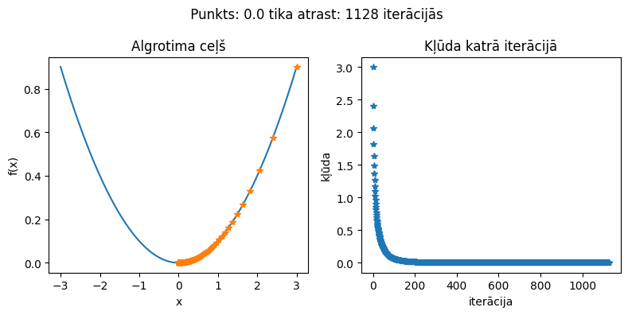

```python
x0 = 3
delta_f = lambda x: 2*x/10
xxx = np.arange(-3,3,0.01)
iter = [x0]

while np.abs(delta_f(x0)) >=  10**(-6):

    x0 = x0 - delta_f(x0)/ np.sqrt(len(iter))

    iter.append(x0)

iter = np.array(iter)
fig, axs = plt.subplots(1, 2, figsize=(8, 4))
fig.suptitle(' Punkts: ' +   str(round(x0,2)) +  " tika atrast: " + str(len(iter)-1) +  " iterācijās")
axs[0].plot(xxx,  xxx**2/10)
axs[0].plot(iter,iter**2 /10, "*")
axs[0].set_title('Algrotima ceļš')
axs[1].plot(np.abs(iter - 0), '*')
axs[1].set_title('Kļūda katrā iterācijā')
axs[0].set_xlabel('x')
axs[0].set_ylabel('f(x)')
axs[1].set_xlabel('iterācija')
axs[1].set_ylabel('kļūda')
plt.tight_layout()
plt.show()
```

Šajā piemērā konverģence notiek ļoti lēni. Kā pamatojums lēnajau konverģencei ir tas, ka samazinot funkciju par 10 reizēm, tās atvasinājums arī samazinās par 10 reizēm un tas kļūst mazs jau atrodoties tālu prom no punkta, kur atvasinājums pieņem vērtību 0. Un mazu atvasinājuma vērtību reizinot ar mazu soļa garumu, algoritms veic pavisam nelielas izmaiņas.

Taču ja mēs punktā $x_{k}$ zinām virzienu, kurā funkcija aug/dilst, vai lietojot šo informāciju nav iespējams atrast precīzu soļa garumu, kas uzreiz ļautu atrast ekstrēma punktu. Definēsim funkciju: $$ \varphi (h) = f(x_{k} + h \cdot f'(x_{k}))$$

kas ir funkcija no soļa garuma. Ja mēs tagad, k-tajā iterācijā, minimizētu funkciju $\varphi(h)$, mēs atrastu soļa garumu $h$, kas ļautu sasniegt funkcijas $f(x)$ ekstrēma punktu.

Diemžēl, arī šajāgadījumā atrast precīzu soļa garumu ne vienmēr var būt iespējams. Taču pastāv iespēja meklēt soļa garumu tuvināti. Lai atrastu optimālus soļa garumus, var lietot Armijo nosacījumu:

Literatūrā tiek lietots $c_{1} = 10^{-4}$. Šis nosacījums apgalvo, ka sollis būs optimāls, ja tas dos funkcijas vērtību, kas atrodās zem pieskartaisnes punktā $x_{k}$.

Lai lietotu šo algoriutmu, vispirms nepieciešams izvēlēties sākuma soļa fgarumu. Parasti tiek lietots $h=1$. Un katrā solī, tiek pārbaudīts, vai izpildās Armijo nosacījums. Ja neizpildās, tad soļa garums tiek samazināts. Šāds process tiek atkārtots, līdz tiek iegūts pārāks mazs soļa garums vai arī izpildās Armijo nosacījums.

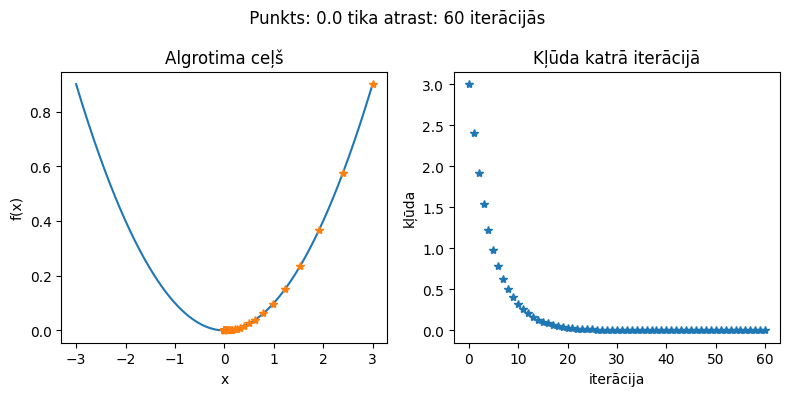

```python
def sola_garums(x, f_atvas,fun):
    h = 1
    c = 10**(-4)
    while h > 10**(-6) and fun( x - h * f_atvas) > fun(x) -  c * h * f_atvas**2:
        h = h* 0.8
    return h

x0 = 3
fun = lambda x:  x**2 / 10
delta_f = lambda x: 2*x/10
xxx = np.arange(-3,3,0.01)
iter = [x0]

while np.abs(delta_f(x0)) >=  10**(-6):
    h = sola_garums(x0,delta_f(x0),fun )
    x0 = x0 - h *  delta_f(x0)
    iter.append(x0)

iter = np.array(iter)
fig, axs = plt.subplots(1, 2, figsize=(8, 4))
fig.suptitle(' Punkts: ' +   str(round(x0,2)) +  " tika atrast: " + str(len(iter)-1) +  " iterācijās")
axs[0].plot(xxx,  xxx**2/10)
axs[0].plot(iter,iter**2 /10, "*")
axs[0].set_title('Algrotima ceļš')
axs[1].plot(np.abs(iter - 0), '*')
axs[1].set_title('Kļūda katrā iterācijā')
axs[0].set_xlabel('x')
axs[0].set_ylabel('f(x)')
axs[1].set_xlabel('iterācija')
axs[1].set_ylabel('kļūda')
plt.tight_layout()
plt.show()
```

Lietojot adaptīvu soļa garumu, ekstrēma punkta funkcijai $ \frac{x^{2}}{10}$ tiek sasniegts ātrā, nekā ņemot $ h_{k} = \frac{1}{\sqrt{k+1}}$. Taču ir iespējams vēl ātrāk, ja soļa garuma meklēšanas algoritmā, sāktu ar soļa garumu, piemēram, $h = 5 $. Šajā piemērā nerodās problēams sākt ar $h=5$, taču būs sarežģītāki piemēri, kuros sākt ar lielāko soļa garumu varētu nosīzmēt, ka pārāk daudz laika tiktu patērēts, lai meklētu soļa garumu.

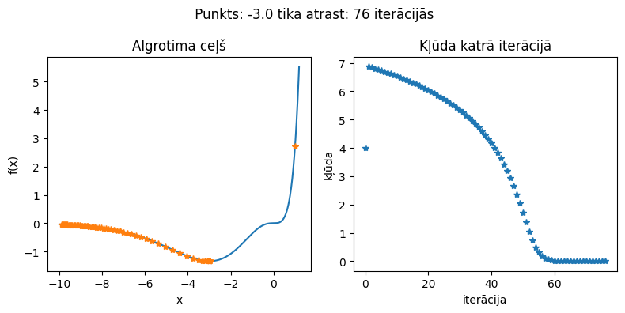

```python
def sola_garums(x, f_atvas,fun):
    h = 1
    c = 10**(-4)
    while h > 10**(-6) and fun( x - h * f_atvas) > fun(x) -  c * h * f_atvas**2:
        h = h* 0.8
    return h

x0 = 1
fun = lambda x:  x**3 * np.exp( x )
delta_f = lambda x: 3*x**2 * np.exp(x) +  x**3 * np.exp( x )
xxx = np.arange(-10,1.2,0.01)
iter = [x0]

while np.abs(delta_f(x0)) >=  10**(-6):
    h = sola_garums(x0,delta_f(x0),fun )
    x0 = x0 - h *  delta_f(x0)
    iter.append(x0)

iter = np.array(iter)
fig, axs = plt.subplots(1, 2, figsize=(8, 4))
fig.suptitle(' Punkts: ' +  str(round(x0,2)) +  " tika atrast: " + str(len(iter)-1) +  " iterācijās")
axs[0].plot(xxx,  fun(xxx))
axs[0].plot(iter,fun(iter), "*")
axs[0].set_title('Algrotima ceļš')
axs[0].set_xlabel('x')
axs[0].set_ylabel('f(x)')
axs[1].plot(np.abs(iter - (-3)), '*')
axs[1].set_title('Kļūda katrā iterācijā')
axs[1].set_xlabel('iterācija')
axs[1].set_ylabel('kļūda')
plt.tight_layout()
plt.show()
```

### Vairākas dimensijas

Līdz šim tika aplūkoti piemēri, kur funkcija ir viendimensionāla. Bet kas notiek, ja tiktu aplūkota funkcija, piemēram, divās dimensijās? Vispirms nepieciešams atvasinājums. Vairāku dimensiju gadījumā, atvasinājuma jēdzienu aizvieto gradients:

$$ \nabla f(x) = \big( \frac{\partial f }{\partial x_{1}}, \ldots, \frac{\partial f }{\partial x_{n}} \big)$$

kas ir vektors no parciāliem atvasinājumiem. Parciālais atvasinājums pēc $x_{1}$ ir vienkārši funkcijas atvasinājums $ x_{1}$ virzienā. Pieņemsim, ka $f(x) = x_{1}^{2} + x_{2}^{2}$. Tad

1. $\frac{\partial f }{\partial x_{1}} = 2x_{1}$
2. $\frac{\partial f }{\partial x_{2}} = 2x_{2}$

Atvasinot funkciju pēc arguemtna $x_{1}$, pārējos mainīgos var interpretēt kā konstantes. Piemēram, ja $f(x) = x_{1}^{3} x_{2}^{2} + x_{2}^{2} x_{1} + x_{1} $, tad

1. $\frac{\partial f }{\partial x_{1}} = 3 x_{1}^{2} x_{2}^{2} + x_{2}^{2} + 1 $
2. $\frac{\partial f }{\partial x_{2}} = 2 x_{1}^{3} x_{2} + 2x_{1} x_{2} $

Atgriežoties pie piemēra: $f(x) = x_{1}^{2} + x_{2}^{2}$

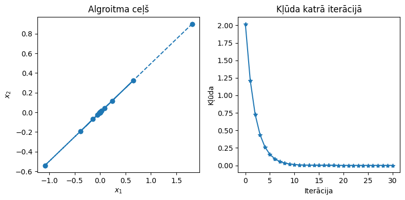

```python
def sola_garums(x, f_atvas,fun):
    h = 1
    c = 10**(-4)
    while h > 10**(-6) and fun( x - h * f_atvas) > fun(x) -  c * h *  np.dot( f_atvas, f_atvas):
        h = h* 0.8
    return h

x0 =  np.random.rand(2) * 2

fun = lambda x:   x[0]**2 + x[1]**2
delta_f_x = lambda x:  np.array([  2*x[0], 2*x[1] ])
iter = [x0]

while np.linalg.norm( delta_f_x(x0)) >=  10**(-6):

    h = sola_garums(x0, delta_f_x(x0),fun )
    x0 = x0 - h * delta_f_x(x0)
    iter.append(x0)

x_val, y_val= zip(*iter)

fig, axs = plt.subplots(1, 2, figsize=(8, 4))

axs[0].scatter(x_val, y_val)
axs[0].plot(x_val, y_val, linestyle='--', marker='o')
axs[0].set_title('Algroitma ceļš')
axs[0].set_xlabel(r'$x_1$')
axs[0].set_ylabel(r'$x_2$')

errors = [np.linalg.norm(point) for point in iter]
axs[1].plot(errors, '*-')
axs[1].set_title('Kļūda katrā iterācijā')
axs[1].set_xlabel('Iterācija')
axs[1].set_ylabel('Kļūda')
plt.tight_layout()
plt.show()
```

Un tālak var aplūkosim funkciju aproksimāiciju. Pieņemsim, ka ir doti dati:

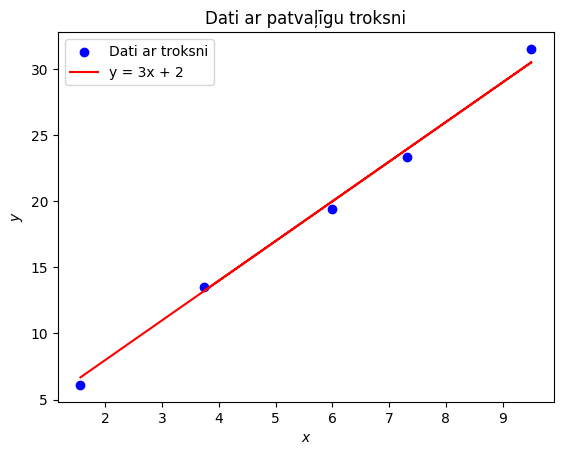

```python
np.random.seed(42)
x_values = np.random.rand(5) * 10


noise = np.random.randn(5)
y_values = 3 * x_values + 2 + noise


plt.scatter(x_values, y_values, color='blue', label='Dati ar troksni')
plt.plot(x_values, 3 * x_values + 2, color='red', label='y = 3x + 2')
plt.xlabel(r'$x$')
plt.ylabel(r'$y$')
plt.title('Dati ar patvaļīgu troksni')
plt.legend()
plt.show()
```

Un mums interesētu aproksimēt šos datus ar lineāru funkciju. Kā to izdarīt? Mēs grivbam atrast vērtības $a$ un $b$, lai $ax + b $ vislabāk aproksimētu mūsu datus. Ar $\tilde{X} = ( \tilde{x_{1}}, \ldots, \tilde{x_{n}})$ un $\tilde{Y} = ( \tilde{y_{1}}, \ldots, \tilde{y_{n}})$ apzīmēsim dotos datus. Var novērot, ka dotos datus var uzrakstīt kā lineāru sistēmu:

$$ \big[ \tilde{X}, 1 \big] \cdot (a,b)^{T} = \tilde{Y} $$

jeb

$$ \tilde{x_{1}} a + b = \tilde{y_{1}} $$$$ \tilde{x_{2}} a + b = \tilde{y_{2}} $$$$ \ldots $$

$$ \tilde{x_{n}} a + b = \tilde{y_{n}} $$

Apzīmēsim $\big[ \tilde{X}, 1 \big] = A $ , $ (a,b)^{T} = x$ un $\tilde{Y} = B$. Līdz ar to var uzrakstīt sistēmu $Ax = B$. Mums interesē minimizēt distandi starp $Ax$ un $B$ jeb $ \min \|Ax- B \|^{2} $

Var parādīt, ka šo distanci minimizē atrisinājums lineārāi sistēmai:

$$A^{T } A x = A^{T} B $$

Apskatam:

$$ x_{k+1} = x_{k} - h_{k} (A^T A x_{k} - A^T B) = x_{k} + h_{k} e_{k} $$

kur $ e_{k} = A^T b - A^T A x_{k}$ . Var izteikt, ka kļūdu minimizē $ h_{k} = \frac{e_{k} \cdot e_{k}}{ A^T A e_{k} \cdot e_{k} } $

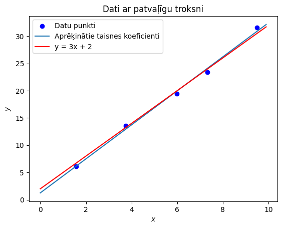

```python
x0 =  np.random.rand(2) * 2

A =  np.array([x_values , np.ones(5,)]).T
B =  np.dot( A.T , y_values.T)
A = np.dot(A.T, A)

iter = [x0]

while True:

    e_k =  B - np.dot(A,x0)
    if np.linalg.norm(e_k ) < 10**(-8):
        break
    h_k =  np.dot(e_k, e_k)/np.dot( np.dot(A,e_k),e_k)
    x0 = x0 + np.dot( h_k , e_k)
    iter.append(x0)



xxx = np.arange(0, 10, 0.1)

plt.scatter(x_values, y_values, color='blue', label='Datu punkti ')
plt.plot( xxx,  x0[0] *xxx + x0[1], label= "Aprēķinātie taisnes koeficienti"  )
plt.plot( xxx, 3 *xxx+ 2,color='red', label='y = 3x + 2')
plt.xlabel(r'$x$')
plt.ylabel(r'$y$')
plt.title('Dati ar patvaļīgu troksni')
plt.legend()
plt.show()
```

Var redzēt, ka taisnes nesakrīt. Aprēķināsim kļūdas:

```python
kluda_aprekinata = 0
kluda_istaTaisne = 0

for id_x,X in enumerate(x_values):
    kluda_aprekinata +=   np.abs( y_values[id_x] - ( x0[0]  * X + x0[1]  ))
    kluda_istaTaisne +=   np.abs( y_values[id_x] - (  3 * X + 2))


print("Kļūda aprēķinot taisnes koeficientus: ", kluda_aprekinata)
print("Kļūda ar dotajiem taisnes koeficientiem: ", kluda_istaTaisne)
```

```
Kļūda aprēķinot taisnes koeficientus:  2.411348530542794
Kļūda ar dotajiem taisnes koeficientiem:  2.966984683962468
```

Var redzēt, ka pie neliela skaita punktu, var atrast koeficientus, kas labāk apraksta datus, nekā dotie koeficienti.